# Homework 6

Jasmine Nakayama

April 6, 2018

Link to repository: (https://github.com/jynakay/Assignments)[https://github.com/jynakay/Assignments]

```r
# load libraries and dataset
library(tidyverse)
library(haven)
library(car)
library(ROCR)
```

```r
helpdata <- haven::read_spss("helpmkh.sav")

# choose variable
h1 <- helpdata %>%
  select(age, female, pss_fr, homeless,
         pcs, mcs, cesd)

# add dichotomous variable to indicate depression for people with CESD scores >= 16
h1 <- h1 %>%
  mutate(cesd_gte16 = cesd >= 16)

# change cesd_gte16 LOGIC variable type to numeric coded 1=TRUE and 0=FALSE
h1$cesd_gte16 <- as.numeric(h1$cesd_gte16)

# check final data subset h1
summary(h1)
```

```
##       age            female           pss_fr          homeless
##  Min.   :19.00   Min.   :0.0000   Min.   : 0.000   Min.   :0.0000
##  1st Qu.:30.00   1st Qu.:0.0000   1st Qu.: 3.000   1st Qu.:0.0000
##  Median :35.00   Median :0.0000   Median : 7.000   Median :0.0000
##  Mean   :35.65   Mean   :0.2362   Mean   : 6.706   Mean   :0.4614
##  3rd Qu.:40.00   3rd Qu.:0.0000   3rd Qu.:10.000   3rd Qu.:1.0000
##  Max.   :60.00   Max.   :1.0000   Max.   :14.000   Max.   :1.0000
##       pcs             mcs              cesd         cesd_gte16
##  Min.   :14.07   Min.   : 6.763   Min.   : 1.00   Min.   :0.0000
##  1st Qu.:40.38   1st Qu.:21.676   1st Qu.:25.00   1st Qu.:1.0000
##  Median :48.88   Median :28.602   Median :34.00   Median :1.0000
##  Mean   :48.05   Mean   :31.677   Mean   :32.85   Mean   :0.8985
##  3rd Qu.:56.95   3rd Qu.:40.941   3rd Qu.:41.00   3rd Qu.:1.0000
##  Max.   :74.81   Max.   :62.175   Max.   :60.00   Max.   :1.0000
```

### 1. [Model 1] Run a simple linear regression (`lm()`) for `cesd` using the `mcs` variable, which is the mental component quality of life score from the SF36.

```r
slr<-lm(cesd~mcs, data=h1)
slr
```

```
##
## Call:
## lm(formula = cesd ~ mcs, data = h1)
##
## Coefficients:
## (Intercept)          mcs
##     53.9022      -0.6647
```

### 2. Write the equation of the final fitted model (i.e. what is the intercept and the slope)? Write a sentence describing the model results (interpret the intercept and slope).

`cesd=53.9022-0.6647*mcs`

For every 1 point increase in MCS score, the CEDS score decreases by 0.6647. Generally, better mental health is associated with lower depression score. Those with an MCS score of 0 will have a CESD of 53.9022.

### 4. [Model 2] Run a second linear regression model (`lm()`) for the `cesd` putting in all of the other variables:

```r
mlr<-lm(cesd~age +female +pss_fr +homeless +pcs +mcs, data=h1)
summary(mlr)
```

```
##
## Call:
## lm(formula = cesd ~ age + female + pss_fr + homeless + pcs +
##     mcs, data = h1)
##
## Residuals:
##      Min       1Q   Median       3Q      Max
## -25.1711  -5.9894  -0.2077   5.5706  27.3137
##
## Coefficients:
##             Estimate Std. Error t value Pr(>|t|)
## (Intercept) 65.30046    3.18670  20.492  < 2e-16 ***
## age         -0.01348    0.05501  -0.245   0.8065
## female       2.35028    0.98810   2.379   0.0178 *
## pss_fr      -0.25569    0.10567  -2.420   0.0159 *
## homeless     0.46545    0.84261   0.552   0.5810
## pcs         -0.23639    0.03987  -5.929  6.1e-09 ***
## mcs         -0.62093    0.03261 -19.042  < 2e-16 ***
## ---
## Signif. codes:  0 '***' 0.001 '**' 0.01 '*' 0.05 '.' 0.1 ' ' 1
##
## Residual standard error: 8.683 on 446 degrees of freedom
## Multiple R-squared:  0.5249, Adjusted R-squared:  0.5185
## F-statistic: 82.14 on 6 and 446 DF,  p-value: < 2.2e-16
```

### 5. Which variables are significant in the model? Write a sentence or two describing the impact of these variables for predicting depression scores (HINT: interpret the coefficient terms).

When adjusting for the other variables in the model, the following variables are significant in the model: `female`, `pss_fr`, `pcs`, and `mcs`. When adjusting for the other variables, a 1 unit increase in `female` results in a 2.35028 increase in `cesd`, and a 1 unit increase in `pss_fr`, `pcs`, or `mcs` results in a 0.25569, 0.23639, or 0.62093 decrease in `cesd` respectively.

### 6. generate the diagnostic plots for this model with these 6 predictors (e.g. get the residual plot by variables, the added-variable plots, the Q-Q plot, diagnostic plots). Also run the VIFs to check for multicollinearity issues.

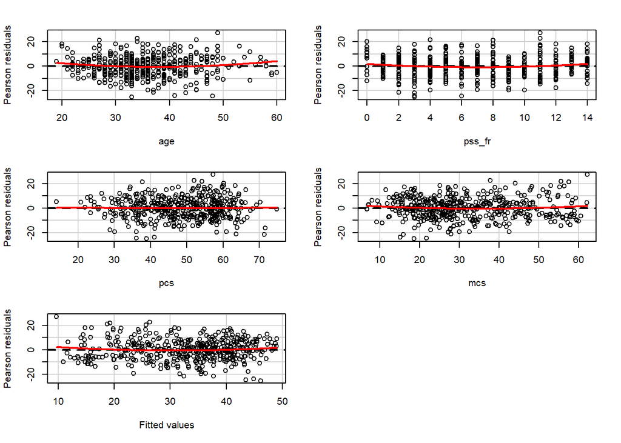

```
##            Test stat Pr(>|t|)
## age            1.941    0.053
## pss_fr         1.964    0.050
## pcs            0.081    0.936
## mcs            1.260    0.208
## Tukey test     1.434    0.152
```

```r
residualPlots(mlr)
```

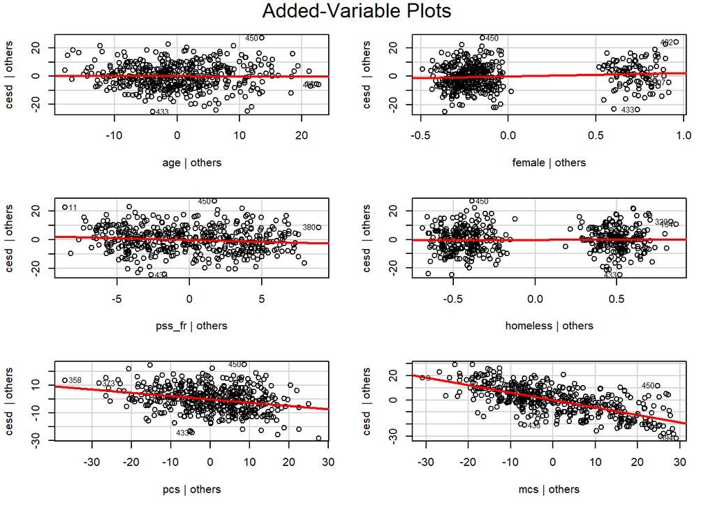

```r
avPlots(mlr, id.n=2, id.cex=0.7)
```

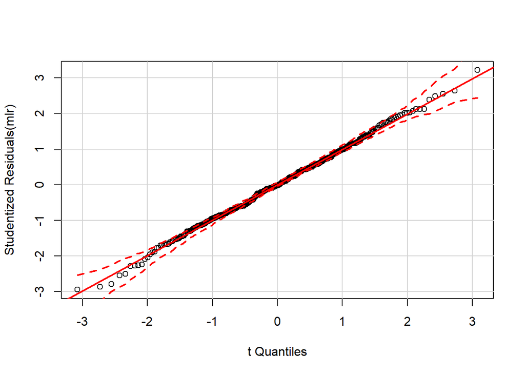

```r
qqPlot(mlr)
```

```r
outlierTest(mlr)
```

```
##
## No Studentized residuals with Bonferonni p < 0.05
## Largest |rstudent|:
##     rstudent unadjusted p-value Bonferonni p
## 450 3.218868          0.0013811      0.62564
```

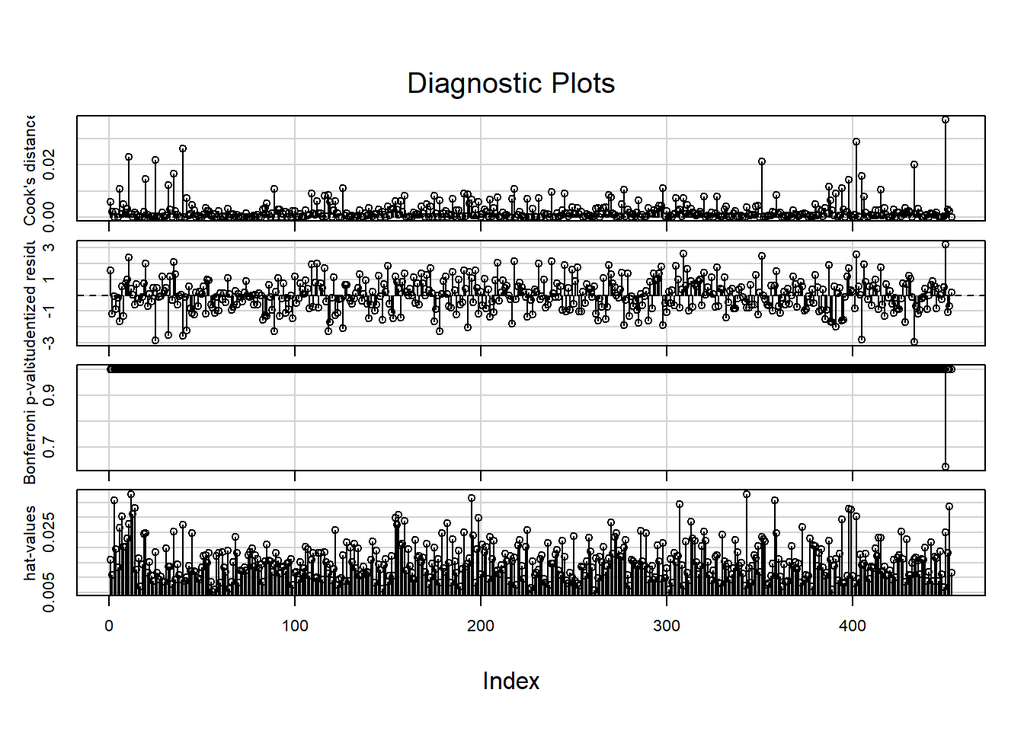

```r
influenceIndexPlot(mlr)
```

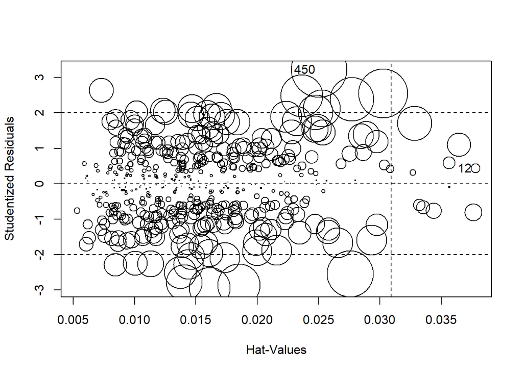

```
##       StudRes        Hat       CookD
## 12  0.4313265 0.03779399 0.001045833
## 450 3.2188680 0.02502996 0.037218269
```

```r
influencePlot(mlr)
```

```r
vif(mlr)
```

```
##      age   female   pss_fr homeless      pcs      mcs
## 1.078264 1.058232 1.068213 1.060007 1.108172 1.050768
```

### 7. [Model 3] Repeat Model 1 above, except this time run a logistic regression (`glm()`) to predict CESD scores => 16 (using the `cesd_gte16` as the outcome) as a function of `mcs` scores. Show a summary of the final fitted model and explain the coefficients.

```r
glm <- glm(cesd_gte16 ~ mcs,
  family=binomial(logit), data=h1)
summary(glm)
```

```
##
## Call:
## glm(formula = cesd_gte16 ~ mcs, family = binomial(logit), data = h1)
##
## Deviance Residuals:
##      Min        1Q    Median        3Q       Max
## -3.04167   0.06727   0.13027   0.29676   1.79914
##
## Coefficients:
##             Estimate Std. Error z value Pr(>|z|)
## (Intercept)   9.2691     1.0621   8.727  < 2e-16 ***
## mcs          -0.1716     0.0219  -7.835 4.68e-15 ***
## ---
## Signif. codes:  0 '***' 0.001 '**' 0.01 '*' 0.05 '.' 0.1 ' ' 1
##
## (Dispersion parameter for binomial family taken to be 1)
##
##     Null deviance: 297.59  on 452  degrees of freedom
## Residual deviance: 174.73  on 451  degrees of freedom
## AIC: 178.73
##
## Number of Fisher Scoring iterations: 7
```

```r
exp(coef(glm))  # Exponentiated coefficients ("odds ratios")
```

```
##  (Intercept)          mcs
## 1.060544e+04 8.423518e-01
```

### 8. Use the `predict()` function like we did in class to predict CESD => 16 and compare it back to the original data. For now, use a cutoff probability of 0.5 - if the probability is > 0.5 consider this to be true and false otherwise.

```
+ How well did the model correctly predict CESD scores => 16 (indicating depression)? (make the "confusion matrix" and look at the true positives and true negatives versus the false positives and false negatives).
```

```r
glm.predict <- predict(glm, newdata=h1,
                      type="response")
table(h1$cesd_gte16, glm.predict > 0.5)
```

```
##
##     FALSE TRUE
##   0    22   24
##   1    12  395
```

```r
t1 <- table(glm.predict > 0.5, h1$cesd_gte16)
t1
```

```
##
##           0   1
##   FALSE  22  12
##   TRUE   24 395
```

### 9. Make an ROC curve plot and compute the AUC and explain if this is a good model for predicting depression or not.

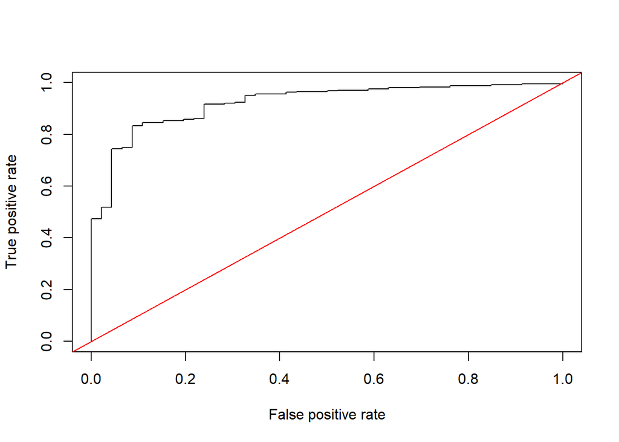

```r
p <- predict(glm, newdata=h1,
             type="response")
pr <- prediction(p, as.numeric(h1$cesd_gte16))
prf <- performance(pr, measure = "tpr", x.measure = "fpr")
plot(prf)
abline(a=0, b=1, col="red")
```

```r
auc <- performance(pr, measure = "auc")
auc <- auc@y.values[[1]]
auc
```

```
## [1] 0.9221771
```

AUC of 0.922 is great, so this is a good model to predict depression.

### 10. Make a plot showing the probability curve - put the `mcs` values on the X-axis and the probability of depression on the Y-axis. Based on this plot, do you think the `mcs` is a good predictor of depression?

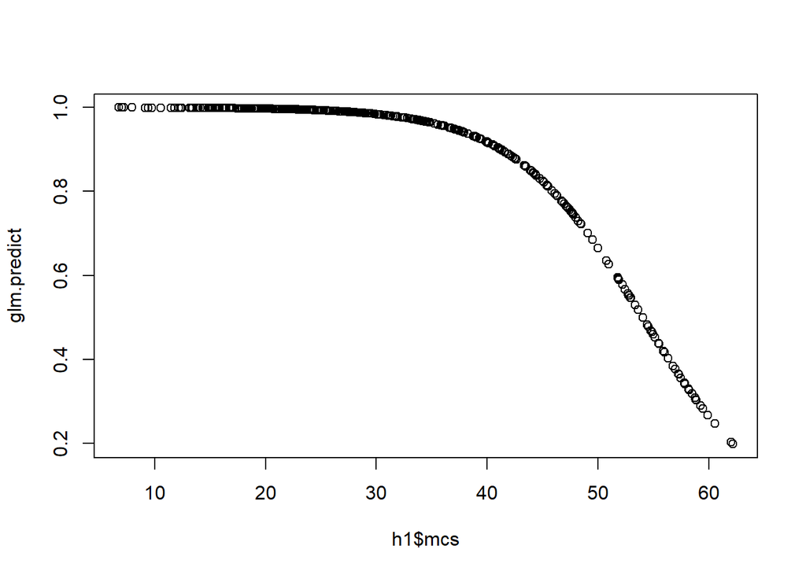

```r
plot(h1$mcs, glm.predict)
```

MCS less than 30 seems to indicate depression. With MCS scores greater than 30, higher scores indicate less depression.